# DATA605 ASSIGNMENT 5

```r
library(tidyverse)
```

# 1 Problem Set 1

Choose independently two numbers B and C at random from the interval [0, 1] with uniform density. Prove that B and C are proper probability distributions.

Note that the point (B,C) is then chosen at random in the unit square.

Find the probability that

1. B+C < 1/2
2. BC < 1/2
3. |B-C| < 1/2
4. max{B,C} < 1/2
5. min{B,C} < 1/2

**Answer:**

## 1.1 Proof

**Prove that B and C are proper probability distributions.**

**(1)** $\because$ B and C at chosen randomly from the interval [0, 1] with uniform density

$\therefore$ The probability density function of B (or C) is
$$f(x)=1 \;\;\;\;\;\; for \;\;0\leq x \leq 1$$

$\therefore$ The cumulative distribution function is
$$F(x) = \int_{0}^{x}f(x)dx=\int_{0}^{x}1dx= x |^{x}_{0} =x \;\;\;\;\;\; for\;\;\;\; 0\leq x \leq 1$$

$\therefore$ $F(x = 1) = 1$, The sum of probability of all values of B (or C) equals 1, both B and C are proper probability distributions.

**(2)** $\because$ B and C are independently selected

$\therefore$ the joint probability density function of B & C is
$$f(x,y) = f(x)f(y) = 1\cdot1=1 \;\;\;\;\;\; for \;\;0\leq x\leq 1\;\; and \;\;0\leq y\leq 1$$

$\therefore$ the joint cumulative distribution function is
$$F(x,y) = \int_{0}^{x} \int_{0}^{y} 1dydx\;\;\;\;\;\; for \;\;0\leq x\leq 1\;\; and \;\;0\leq y\leq 1$$

$\therefore$
$$F(x =1, y = 1) = \int_{0}^{1} \int_{0}^{1} 1dydx =\int_{0}^{1} \left[ y \right]^{1}_{0}dx=\int_{0}^{1}1dx=\left[ x \right]^{1}_{0}=1$$
, the joint probability of B & C is a proper probability distribution.

## 1.2 Question 1(a)

1. B+C < 1/2

### 1.2.1 By Graph

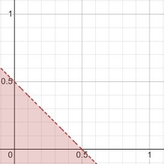

Figure for Question 1a

Graph the line $X< \frac{1}{2}-Y$ on a graph, we have the shaded area within the unit square
$$=\frac{1}{2}\cdot\frac{1}{2}\cdot\frac{1}{2} =\frac{1}{8}$$

### 1.2.2 By Integration

$$P(B+C<1/2)$$
$$=P(0<x<\frac{1}{2}, 0<y<\frac{1}{2}-x)$$
$$=\int_{0}^{1/2} \int_{0}^{1/2-x} f(x,y) dydx$$
$$=\int_{0}^{1/2} \int_{0}^{1/2-x} 1dydx$$
$$=\int_{0}^{1/2} [\frac{1}{2}-x]dx$$
$$=\left[ \frac{x}{2}-\frac{x^{2}}{2} \right]^{1/2}_{0}$$
$$=\frac{1}{4}-\frac{1}{8}$$
$$=\frac{1}{8}$$

### 1.2.3 By Code

```r
integrate((function(x){
  integrate(function(y) {0*y+1},0,0.5-x)$value}) %>%
    Vectorize(),0,0.5)
```

```
## 0.125 with absolute error < 1.4e-15
```

## 1.3 Question 1(b)

2. BC < 1/2

### 1.3.1 By Graph

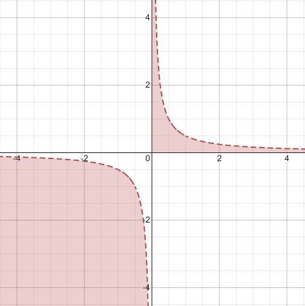

Figure for Question 1bi

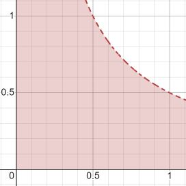

Figure for Question 1bii

### 1.3.2 By Integration

$$P(BC < \frac{1}{2})$$
$$=P(xy < \frac{1}{2})$$
$$=P(y < \frac{1}{2x})$$
$$=\int_{0}^{1/2} \int_{0}^{1} 1 dydx + \int_{1/2}^{1} \int_{0}^{\frac{1}{2x}} 1 dydx$$

$$=\frac{1}{2} + \int_{1/2}^{1} \frac{1}{2x} dx$$

$$=\frac{1}{2} + \frac{1}{2}\cdot \left [ ln(x) \right ]^{1}_{1/2}$$
$$=\frac{1}{2} - \frac{1}{2} \cdot (ln(\frac{1}{2}))$$
$$\approx 0.84657359$$

### 1.3.3 By Code

```r
integrate((function(x){
  integrate(function(y) {0*y+1},0,1)$value}) %>%
    Vectorize(),0,0.5)$value +
integrate((function(x){
  integrate(function(y) {0*y+1},0,1/(2*x))$value}) %>%
    Vectorize(),0.5,1)$value
```

```
## [1] 0.8465736
```

## 1.4 Question 1(c)

3. |B-C| < 1/2

### 1.4.1 By Graph

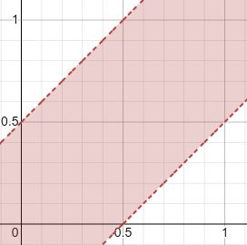

Figure for Question 1c

Graph the line $|x-y|<\frac{1}{2}$ on a graph, calculate the shaded area within the unit square as sum of two symmetric trapezoids
$$=(\frac{1}{2}+1)\cdot\frac{1}{2}\cdot\frac{1}{2}\cdot2=\frac{3}{4}$$

### 1.4.2 By Integration

$$P(\left | B-C \right | < \frac{1}{2})$$
$$=P(-\frac{1}{2} < x-y < \frac{1}{2})$$
$$=P((y<x+\frac{1}{2}) and (y>x-\frac{1}{2}))$$
$$=\int_{0}^{1/2} \int_{0}^{x+1/2} 1 dydx + \int_{1/2}^{1} \int_{x-1/2}^{1} 1 dydx$$
$$=\int_{0}^{1/2}(x+\frac{1}{2})dx + \int_{1/2}^{1}(\frac{3}{2}-x)dx$$
$$=\left [ \frac{x^{2}}{2}+\frac{x}{2} \right ]^{1/2}_{0} + \left [ \frac{3x}{2} - \frac{x^{2}}{2} \right ]^{1}_{1/2}$$
$$=(\frac{1}{8}+\frac{1}{4})-0+(\frac{3}{2}-\frac{1}{2})-(\frac{3}{4}-\frac{1}{8})$$
$$=\frac{3}{4}$$

### 1.4.3 By Code

```r
integrate((function(x){
  integrate(function(y) {0*y+1},0,x+0.5)$value}) %>%
    Vectorize(),0,0.5)$value +
integrate((function(x){
  integrate(function(y) {0*y+1},x-0.5,1)$value}) %>%
    Vectorize(),0.5,1)$value
```

```
## [1] 0.75
```

## 1.5 Question 1(d)

4. max{B,C} < 1/2

### 1.5.1 By Graph

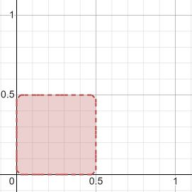

Figure for Question 1d

Graph the line $max\left\{B,C\right\}<\frac{1}{2}$ on a graph, calculate the shaded area within the unit square
$$=\frac{1}{2}\cdot\frac{1}{2}=\frac{1}{4}$$

### 1.5.2 By Integration

$$P(max\left\{B,C\right\}<\frac{1}{2})$$
$$=P(max\left\{x,y\right\}<\frac{1}{2})$$
$$=P((0<x<\frac{1}{2}) and (0<y<\frac{1}{2}))$$
$$\int_{0}^{1/2}\int_{0}^{1/2} 1 \;dy\,dx$$
$$=\frac{1}{2} \cdot \frac{1}{2}$$
$$=\frac{1}{4}$$

### 1.5.3 By Code

```r
integrate((function(x){
  integrate(function(y) {0*y+1},0,0.5)$value}) %>%
    Vectorize(),0,0.5)$value
```

```
## [1] 0.25
```

## 1.6 Question 1(e)

5. min{B,C} < 1/2

### 1.6.1 By Graph

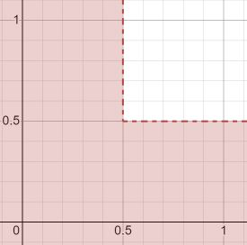

Figure for Question 1e

Graph the line $min\left\{B,C\right\}<\frac{1}{2}$ on a graph, calculate the shaded area within the unit square
$$=1-\frac{1}{2}\cdot\frac{1}{2}=\frac{3}{4}$$

### 1.6.2 By Integration

$$P(min\left\{B,C\right\}<\frac{1}{2})$$
$$=P(min\left\{x,y\right\}<\frac{1}{2})$$
$$=P((x<\frac{1}{2})or(y<\frac{1}{2}))$$
$$=\int_{0}^{1/2}\int_{0}^{1} 1dydx + \int_{1/2}^{1}\int_{0}^{1/2}1dydx$$
$$=\frac{1}{2} + \frac{1}{4}$$
$$=\frac{3}{4}$$

### 1.6.3 By Code

```r
integrate((function(x){
  integrate(function(y) {0*y+1},0,1)$value}) %>%
    Vectorize(),0,0.5)$value +
integrate((function(x){
  integrate(function(y) {0*y+1},0,0.5)$value}) %>%
    Vectorize(),0.5,1)$value
```

```
## [1] 0.75
```

## 1.7 Reference

Graphing Tool: https://www.mathway.com/Algebra